# Data Expo 2009 - Airline on-time performance

## by (mahmoud lotfi)

## key findings:

1. Flights status distribution in 2008
2. Flight delay reasons and how much they contribute to the number of delayed flights
3. The worest day to travel.
4. Which Airlines have the longest delays?
5. What is the worst time of day to travel?

## insights :

1. It turn out most of flight arrive early , nearly 70%.
2. We also see that the weather is not the main reason for delays. Weather only contributes to 2% of the delays.
3. The wostest arrival time delay ocurr Tuesday for most of carriers
4. B6 had the worst for arrivals delay and the lowest departure delay, while AQ, HA and YV has the lowest arravial delay
5. unstable arrival delay between 12:00 AM to 05:00 AM, a huge crowd gathered between 05:00 AM to 06:00 AM

## Dataset Overview

- The data consists of flight arrival and departure details for all commercial flights within the USA, from October 1987 to April 2008.
- This is a large dataset: there are nearly 120 million records in total, and takes up 1.6 gigabytes of space compressed and 12 gigabytes when uncompressed.
- The data comes originally from RITA where it is described in detail.
- the data in bzipped csv file.
- These files have derivable variables removed, are packaged in yearly chunks and have been more heavily compressed than the originals.
- in this project we will discuss flight delay for **2008** data set

## Flights status distribution in 2008

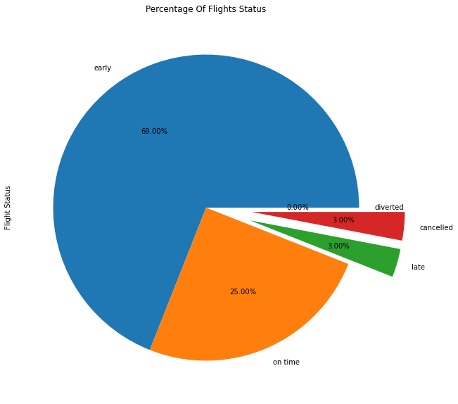

> It turn out most of flight arrive early , nearly 70%

## Flight delay reasons and how much they contribute to the number of delayed flights

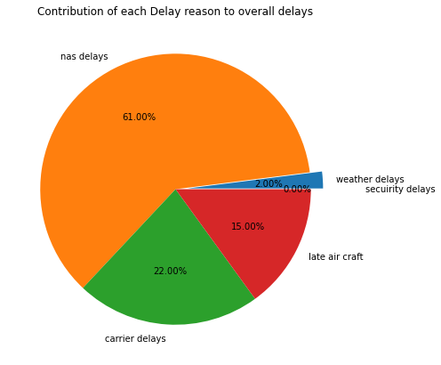

> We also see that the weather is not the main reason for delays. Weather only contributes to 2% of the delays.

## The worest day to travel

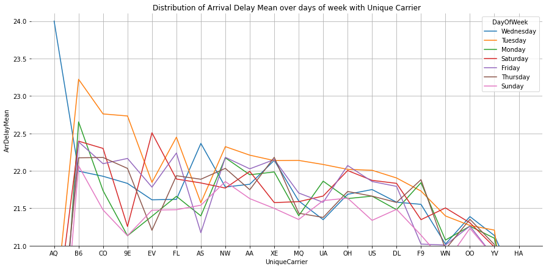

> The wostest arrival time delay ocurr Tuesday for most of carriers

## Which Airlines have the longest delays

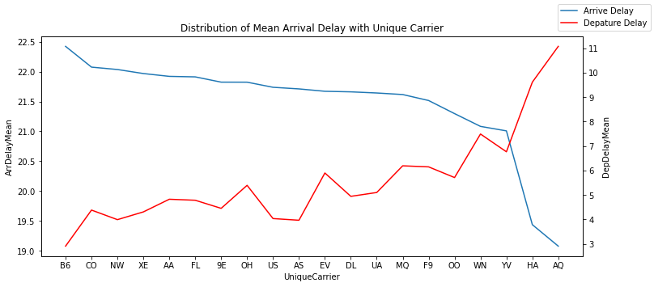

> B6 had the worst for arrivals delay and the lowest departure delay, while AQ, HA and YV has the lowest arravial delaY

## What is the worst time of day to travel?

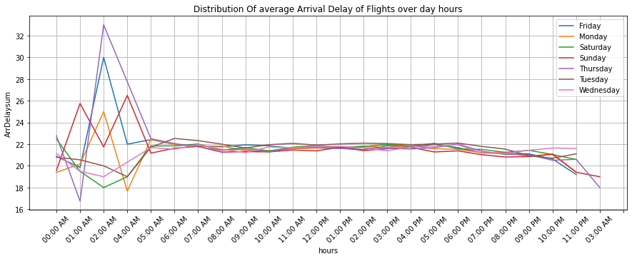

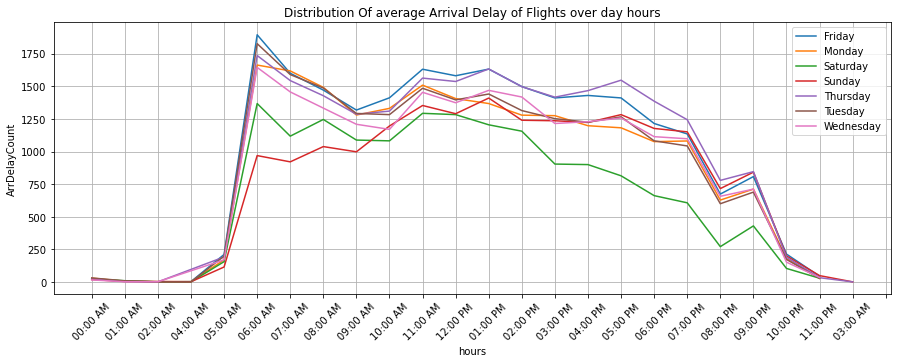

- unstable arrival delay between 12:00 AM to 05:00 AM
- a huge crowd gathered between 05:00 AM to 06:00 AM